# Interactive analysis Report

Rhys

2024-04-11

```r
example_code <- penguins %>%
  mutate(Penguin_bill_surface_area = bill_length_mm * bill_depth_mm)
```

## Summary stats

### Overall Summary

For the overall summary table, we will be using the `modelsummmary` package. It has the really cool feature that it will place histograms into your table! It is a very customisable package, with plenty of options to choose from for all sorts of analyses. For more information, please check their [website](https://modelsummary.com/index.html).

Unique

Missing Pct.

Mean

SD

Min

Median

Max

Histogram

Bill Length (mm)

165

1

43.9

5.5

32.1

44.5

59.6

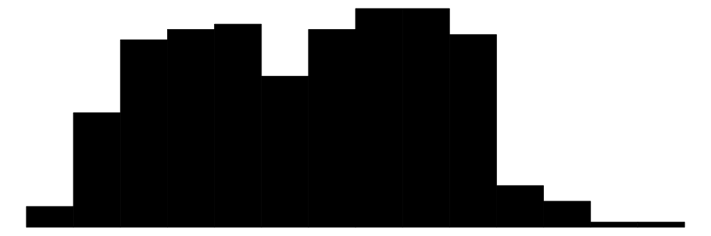

Bill Depth(mm)

81

1

17.2

2.0

13.1

17.3

21.5

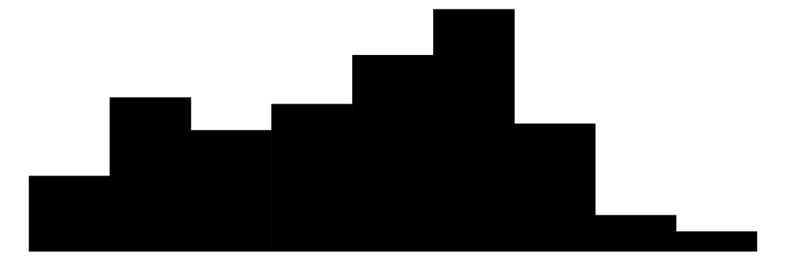

Flipper Length(mm)

56

1

200.9

14.1

172.0

197.0

231.0

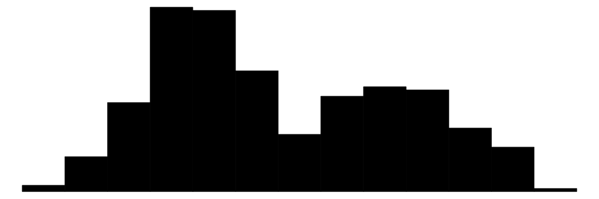

Body Mass(g)

95

1

4201.8

802.0

2700.0

4050.0

6300.0

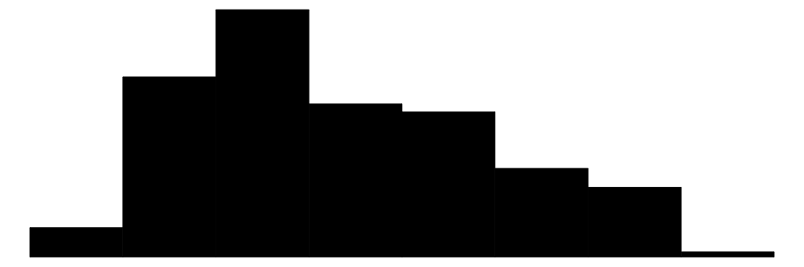

N

%

species

Adelie

152

44.2

Chinstrap

68

19.8

Gentoo

124

36.0

island

Biscoe

168

48.8

Dream

124

36.0

Torgersen

52

15.1

sex

female

165

48.0

male

168

48.8

Unique

Missing Pct.

Mean

SD

Min

Median

Max

Histogram

Bill Length (mm)

165

1

43.9

5.5

32.1

44.5

59.6

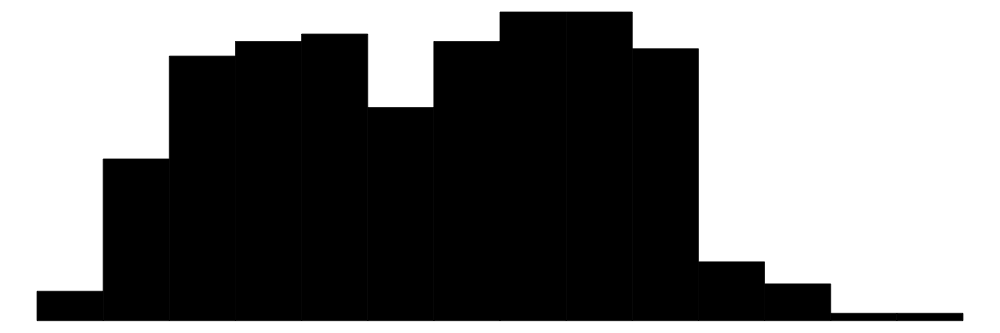

Bill Depth(mm)

81

1

17.2

2.0

13.1

17.3

21.5

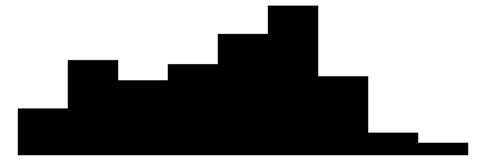

Flipper Length(mm)

56

1

200.9

14.1

172.0

197.0

231.0

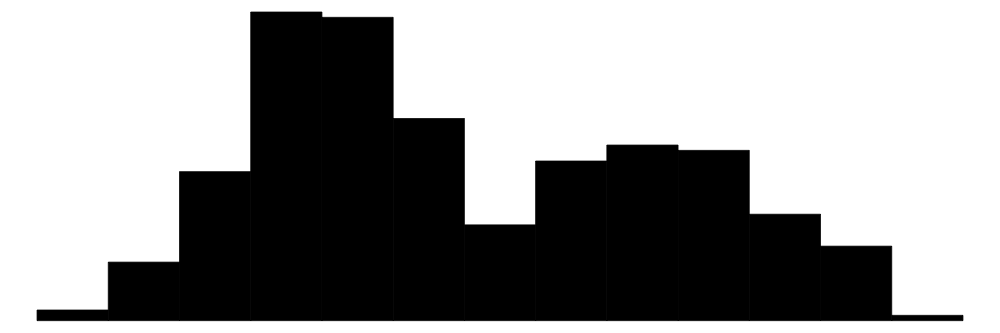

Body Mass(g)

95

1

4201.8

802.0

2700.0

4050.0

6300.0

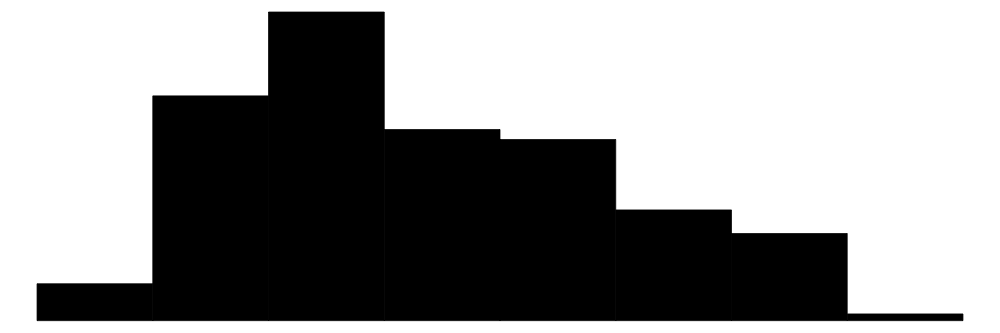

N

%

species

Adelie

152

44.2

Chinstrap

68

19.8

Gentoo

124

36.0

island

Biscoe

168

48.8

Dream

124

36.0

Torgersen

52

15.1

sex

female

165

48.0

male

168

48.8

### By Species

For the within group summaries, we are using the `gtsummary` package. This is another flexible table creator, which I find to be particularly useful and easy to use for subset summaries and analyses. For more information, check out their [website](https://www.danieldsjoberg.com/gtsummary/).

| **Characteristic** | **Adelie**, N = 152<sup>1</sup> | **Chinstrap**, N = 68<sup>1</sup> | **Gentoo**, N = 124<sup>1</sup> |
| --- | --- | --- | --- |
| island |  |  |  |
| Biscoe | 44 (29%) | 0 (0%) | 124 (100%) |
| Dream | 56 (37%) | 68 (100%) | 0 (0%) |
| Torgersen | 52 (34%) | 0 (0%) | 0 (0%) |
| Bill Length (mm) | 38.8 (2.7) | 48.8 (3.3) | 47.5 (3.1) |
| Unknown | 1 | 0 | 1 |
| Bill Depth(mm) | 18.35 (1.22) | 18.42 (1.14) | 14.98 (0.98) |
| Unknown | 1 | 0 | 1 |
| Flipper Length(mm) | 190 (7) | 196 (7) | 217 (6) |
| Unknown | 1 | 0 | 1 |
| Body Mass(g) | 3,701 (459) | 3,733 (384) | 5,076 (504) |
| Unknown | 1 | 0 | 1 |
| sex |  |  |  |
| female | 73 (50%) | 34 (50%) | 58 (49%) |
| male | 73 (50%) | 34 (50%) | 61 (51%) |
| Unknown | 6 | 0 | 5 |

<sup>1</sup> n (%); Mean (SD)